# CaseStudy_spg

Sara Piñas García

2024-05-19

# Case Study: Impact of Lifestyle and Demographic Factors on Sleep Duration through Bayesian linear regression analysis

### May 2024

### NIA 100472784, Group 96

### Bachelor on Data Science and Engineering

## Motivation

My daily routine involves attending university, studying, going to the gym, or practicing different sports, and then sleeping. I believe I have a well-organized schedule that allows me to manage everything efficiently while maintaining a good sleep and eating schedule. Although I spend considerable time in front of a screen, it’s a common aspect of studying engineering. Maintaining good habits and a regular schedule is crucial for a positive mood, balanced hormones, and reduced stress.

It is recommended to sleep at least 7 hours a day for good health, as this helps reduce the risk of certain health issues, alleviates stress, and promotes a healthy lifestyle and improved mood.

For this case study, I aim to analyze data I collected from my circle of acquaintances to determine if this sleep recommendation is generally met and to identify factors that influence the amount of sleep. Specifically, I want to explore whether playing sports results in more sleep, if screen time negatively impacts sleep duration, and how eating patterns affect sleep. Additionally, I will examine the roles of gender and age in sleep patterns.

## My Data

As already mentioned, the data that is going to be used for this study has been gathered by me through a Google Form sent among various friends and family members.

The data has 7 variables and 128 observations, the variables are the following:

**Time:** This variable denotes the timestamp of data collection, it is not relevant for the study.

**Gender:** Categorical variable that indicates the gender of the respondents, with categories such as Male, Female, and Prefer Not To Answer.

**Age:** Continuous variable that represents the age of each respondent, providing information about the age distribution.

**Daily_meals:** This discrete numerical variable indicates the number of meals consumed by each respondent per day.

**Hours_sport_per_week:** Continuous numerical variable that reflects the amount of time each respondent spends on sports or physical activities per week.

**Hours_sleep_per_day:** Continuous numerical variable that indicates the average number of hours of sleep per day for each respondent.

**Hours_screen_per_day:** Continuous numerical variable that represents the amount of time spent by each respondent on screens per day.

## Objective

To investigate the factors that affect the amount of sleep individuals get per day, specifically examining the influence of the previous variables. I will identify and visualize the patterns and trends in sleep duration among different demographic groups, determine which factors significantly predict sleep duration, and explore potential interactions between factors.

## Libraries that will be used

```r
rm(list = ls())
library(ggplot2)
library(tidyverse)
library(hrbrthemes)
library(ggthemes)
library(gridExtra)
library(MCMCpack)
library(R2OpenBUGS)
```

## Data Preprocessing

```r
Mydata = read.csv("ActividadySalud.csv", header = TRUE, sep = ";")
```

The data does not contain any NAs or outliers and it is mostly preprocessed, the columns’ names will be changed for an easier understanding, and the categorical variables will be turned into factors.

```r
new_names <- c("Time", "Gender", "Age", "Daily_meals", "Hours_sport_per_week",
               "Hours_sleep_per_day", "Hours_screen_per_day")
colnames(Mydata)<- new_names
Mydata[, c(3, 5:7)] <- lapply(Mydata[, c(3, 5:7)], as.numeric)
Mydata <- Mydata[, -which(names(Mydata) == "Time")]
Mydata$Daily_meals <- as.factor(Mydata$Daily_meals)
head(Mydata)
```

```
##      Gender Age Daily_meals Hours_sport_per_week Hours_sleep_per_day
## 1 Masculino  20          4+                    4                   6
## 2 Masculino  21           3                    6                  10
## 3  Femenino  21           3                    4                   8
## 4 Masculino  21           3                    0                   7
## 5  Femenino  21          4+                    0                   8
## 6  Femenino  20          4+                    4                   8
##   Hours_screen_per_day
## 1                    7
## 2                    3
## 3                    8
## 4                   12
## 5                   12
## 6                    8
```

```r
summary(Mydata)
```

```
##     Gender               Age       Daily_meals Hours_sport_per_week
##  Length:128         Min.   :16.0   2 : 7       Min.   : 0.000
##  Class :character   1st Qu.:20.0   3 :59       1st Qu.: 2.000
##  Mode  :character   Median :21.0   4+:62       Median : 4.000
##                     Mean   :29.6               Mean   : 5.016
##                     3rd Qu.:27.0               3rd Qu.: 7.000
##                     Max.   :78.0               Max.   :30.000
##  Hours_sleep_per_day Hours_screen_per_day
##  Min.   : 4.000      Min.   : 0.000
##  1st Qu.: 6.000      1st Qu.: 5.000
##  Median : 7.000      Median : 7.000
##  Mean   : 7.031      Mean   : 6.836
##  3rd Qu.: 8.000      3rd Qu.: 9.000
##  Max.   :10.000      Max.   :17.000
```

## Plots of the data

We will plot the histograms of the continouos variables and pie charts of the categorical ones to see probable distributions.

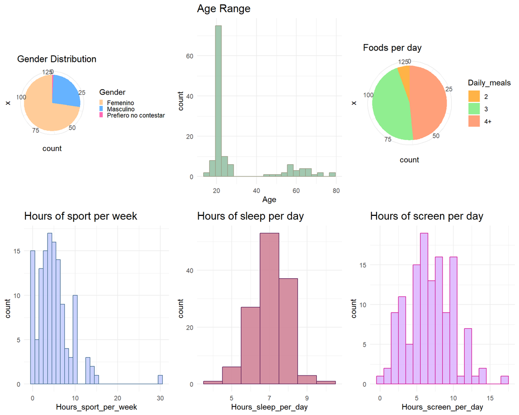

```r
options(
  repr.plot.width = 10,   # Width of the plot in inches
  repr.plot.height = 8   # Height of the plot in inches
)

age <-
  ggplot( Mydata, aes(x=Age)) +
  geom_histogram( binwidth=3, fill="#98c2a7", color="#999b84", alpha=0.9) +
  ggtitle("Age Range") +
  theme_minimal() +
  theme(
    plot.title = element_text(size=15)
  )

sport <-
  ggplot( Mydata, aes(x=Hours_sport_per_week)) +
  geom_histogram( binwidth=1, fill="#c4cdff", color="#497094", alpha=0.9) +
  ggtitle("Hours of sport per week") +
  theme_minimal() +
  theme(
    plot.title = element_text(size=15)
  )

sleep <-
  ggplot( Mydata, aes(x=Hours_sleep_per_day)) +
  geom_histogram( binwidth=1, fill="#d08498", color="#601f58", alpha=0.9, bins = 10) +
  ggtitle("Hours of sleep per day") +
  theme_minimal() +
  theme(
    plot.title = element_text(size=15)
  )

screen <-
  ggplot( Mydata, aes(x=Hours_screen_per_day)) +
  geom_histogram( binwidth=1, fill="#deb7ff", color="#d11799", alpha=0.9, bins = 10) +
  ggtitle("Hours of screen per day") +
  theme_minimal() +
  theme(
    plot.title = element_text(size=15)
  )

gender <-
  ggplot(Mydata, aes(x = "", fill = Gender)) +
  geom_bar(width = 1) +
  coord_polar("y", start = 0) +
  scale_fill_manual(values = c("#ffcc99", "#66b3ff", "#FF69B4")) +
  ggtitle("Gender Distribution") +
  theme_void()+
  theme_minimal() +
  theme(
    legend.key.size = unit(0.2, "cm")  # Adjust the size of the legend fill
  )

food <-
  ggplot(Mydata, aes(x = "", fill = Daily_meals)) +
  geom_bar(width = 1) +
  coord_polar("y", start = 0) +
  scale_fill_manual(values = c("#ffb347", "#90EE90", "#FFA07A"))+
  ggtitle("Foods per day") +
  theme_void()+
  theme_minimal()

grid.arrange(gender, age, food, sport, sleep, screen, nrow = 2)
```

For the gender, let’s turn the variable into a binary variable by removing the ‘Prefiero no contestar’ observation since it is only one and will not tell us much.

```r
Mydata <- Mydata %>% filter(Gender != "Prefiero no contestar")
Mydata$Gender <- as.factor(Mydata$Gender)
```

On the other hand, the “Age Range” plot shows a bimodal distribution with two peaks, indicating the presence of two distinct age groups within the dataset. This observation suggests that there may be two underlying populations contributing to the data: one corresponding to young adults and another to adults.

Let’s deal with my two distinct groups, by explicitly model the two groups:

### 1st: Identify the two modes:

```r
library(mixAK)
```

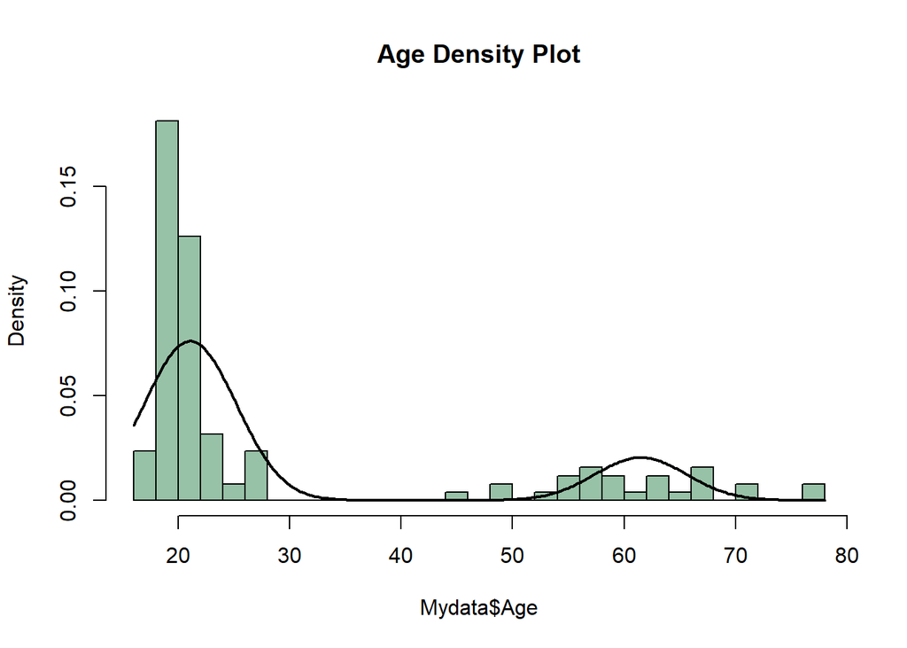

```r
fit.freq <- NMixEM(Mydata$Age, K = 2)
x <- seq(min(Mydata$Age), max(Mydata$Age), length = 300)
fx <- dMVNmixture(x, weight=fit.freq$weight, mean=fit.freq$mean,
                  Sigma=rep(fit.freq$Sigma, fit.freq$K))
hist(Mydata$Age, prob = TRUE, breaks = seq(min(Mydata$Age), max(Mydata$Age), by = 2),
     col = "#98c2a7", main = "Age Density Plot")
lines(x, fx, col="black", lwd=2)
```

By finding the local maxima:

```r
age_density <- density(Mydata$Age)
local_maxima <- function(x) {
  diff_sign <- diff(sign(diff(x)))
  which(diff_sign == -2) + 1
}

modes <- age_density$x[local_maxima(age_density$y)]
modes
```

```
## [1] 20.46445 49.20537 57.74227 66.42146 77.37715
```

The two modes that are shown in the previous histogram are for ages 20 and 58 approximately.

### 2nd: Create Age Groups by categorizing the age feature

```r
Mydata$Age_Group <- ifelse(Mydata$Age <= 30, "Young_Adults", "Adults")
Mydata$Age_Group <- as.factor(Mydata$Age_Group)
table(Mydata$Age_Group)
```

```
##
##       Adults Young_Adults
##           27          100
```

100 young adults and 27 adults.

Now the data is already processed for the study:

```r
head(Mydata)
```

```
##      Gender Age Daily_meals Hours_sport_per_week Hours_sleep_per_day
## 1 Masculino  20          4+                    4                   6
## 2 Masculino  21           3                    6                  10
## 3  Femenino  21           3                    4                   8
## 4 Masculino  21           3                    0                   7
## 5  Femenino  21          4+                    0                   8
## 6  Femenino  20          4+                    4                   8
##   Hours_screen_per_day    Age_Group
## 1                    7 Young_Adults
## 2                    3 Young_Adults
## 3                    8 Young_Adults
## 4                   12 Young_Adults
## 5                   12 Young_Adults
## 6                    8 Young_Adults
```

## Bayesian Linear Regression using MCMCPack

The Bayesian Linear Regression analyzes the relationship between the dependent variable “Hours_sleep_per_day” and the predictors “Gender”, “Age_Group”, “Daily_meals”, “Hours_sport_per_week”, and “Hours_screen_per_day”.

**Target Variable:** Hours of sleep per day

**Predictors:** Age, gender, daily meals, hours of sport per week, hours of screen time per day.

Using MCMCpack:

Initially, I’ll construct a Bayesian regressor with MCMC, incorporating all features to assess their significance (excluding age, which has been categorized).

For the burnin value, I’ll begin with 1000 iterations, and for the MCMC, I’ll set it to 10000 iterations without thinning initially.

```r
bayes.model <- MCMCregress(Hours_sleep_per_day ~ Gender + Age_Group + Daily_meals +
                             Hours_sport_per_week + Hours_screen_per_day, data= Mydata, burnin= 1000, mcmc = 10000)

summary(bayes.model)
```

```
##
## Iterations = 1001:11000
## Thinning interval = 1
## Number of chains = 1
## Sample size per chain = 10000
##
## 1. Empirical mean and standard deviation for each variable,
##    plus standard error of the mean:
##
##                           Mean      SD  Naive SE Time-series SE
## (Intercept)            5.88537 0.48882 0.0048882      0.0048882
## GenderMasculino        0.07824 0.20424 0.0020424      0.0020424
## Age_GroupYoung_Adults  0.47057 0.23963 0.0023963      0.0023481
## Daily_meals3           0.74549 0.39334 0.0039334      0.0039334
## Daily_meals4+          0.72891 0.38803 0.0038803      0.0038803
## Hours_sport_per_week   0.03697 0.02280 0.0002280      0.0002280
## Hours_screen_per_day  -0.01699 0.02924 0.0002924      0.0002924
## sigma2                 0.91446 0.11982 0.0011982      0.0013082
##
## 2. Quantiles for each variable:
##
##                            2.5%      25%      50%      75%   97.5%
## (Intercept)            4.923465  5.55667  5.88712 6.212918 6.84631
## GenderMasculino       -0.320851 -0.05933  0.07796 0.214176 0.48382
## Age_GroupYoung_Adults  0.001330  0.30624  0.46832 0.633244 0.94394
## Daily_meals3          -0.040775  0.48126  0.75121 1.011394 1.50584
## Daily_meals4+         -0.039239  0.46737  0.73673 0.983673 1.48687
## Hours_sport_per_week  -0.007317  0.02181  0.03694 0.052168 0.08172
## Hours_screen_per_day  -0.074429 -0.03659 -0.01698 0.002501 0.04032
## sigma2                 0.707617  0.83027  0.90450 0.986608 1.17587
```

Upon analyzing the summary of the Bayesian model, particularly focusing on the section “Empirical mean and standard deviation for each variable, plus standard error of the mean,” several insights emerge:

The average hours of sleep per day with all predictors considered is approximately **5.89 hours**. Shown by the intercept, in which all variables are in their baseline levels.

The baseline levels of the predictors are the followings:

- For an individual who is female (Gender = “Femenino”),
- Belongs to the adult age group (Age_Group = “Adults”),
- Consumes 2 or fewer meals per day (Daily_meals = “2 or fewer”),
- Does not engage in sports (Hours_sport_per_week = 0),
- And spends no time in front of a screen (Hours_screen_per_day = 0).

On average, males sleep approximately **0.078 hours** more than females.

Young adults sleep around **0.47 hours** more than adults on average.

Those consuming **more than 2 meals** tend to sleep longer.

Each hour of sport participation is associated with an **increase of approximately 0.037 hours** in sleep duration.

Conversely, each hour of screen time corresponds to a **decrease of around 0.017 hours** in sleep duration.

When considering the statistical significance of variables and credible intervals at a 95% level, parameters that do not include zero in their interval suggest a likely non-zero effect. Notably:

These can be seen in here as well for the mean:

```r
beta=bayes.model[,1:7]
sigma2 = bayes.model[,8]

apply(beta, 2,mean)
```

```
##           (Intercept)       GenderMasculino Age_GroupYoung_Adults
##            5.88536608            0.07824451            0.47056657
##          Daily_meals3         Daily_meals4+  Hours_sport_per_week
##            0.74548547            0.72891391            0.03696834
##  Hours_screen_per_day
##           -0.01699003
```

The median:

```r
apply(beta, 2,median)
```

```
##           (Intercept)       GenderMasculino Age_GroupYoung_Adults
##            5.88712485            0.07795554            0.46832299
##          Daily_meals3         Daily_meals4+  Hours_sport_per_week
##            0.75120559            0.73672621            0.03693676
##  Hours_screen_per_day
##           -0.01697872
```

By considering a 95% credible interval, it appears that the variables may not be statistically significant, as the zero value is enclosed within the majority of confidence intervals (CIs). This suggests a lack of evidence to support a significant effect of these variables on the outcome.

```r
apply(bayes.model, 2,quantile, probs = c(0.025,0.975))
```

```
##       (Intercept) GenderMasculino Age_GroupYoung_Adults Daily_meals3
## 2.5%     4.923465      -0.3208514           0.001330059  -0.04077467
## 97.5%    6.846313       0.4838239           0.943941313   1.50583785
##       Daily_meals4+ Hours_sport_per_week Hours_screen_per_day   sigma2
## 2.5%    -0.03923927         -0.007316919          -0.07442895 0.707617
## 97.5%    1.48687196          0.081720802           0.04031802 1.175866
```

By considering an 85% credible interval instead, more zero values fall outside the range, however it comes with the cost of overlooking some true effects that might fall outside these new narrower interval.

```r
apply(bayes.model, 2,quantile, probs = c(0.075,0.925))
```

```
##       (Intercept) GenderMasculino Age_GroupYoung_Adults Daily_meals3
## 7.5%     5.181740      -0.2170989             0.1298349    0.1753887
## 92.5%    6.581571       0.3704881             0.8154904    1.3040756
##       Daily_meals4+ Hours_sport_per_week Hours_screen_per_day   sigma2
## 7.5%      0.1716766          0.003567213          -0.05846372 0.755257
## 92.5%     1.2883526          0.069568455           0.02558460 1.093296
```

## Convergence diagnostic

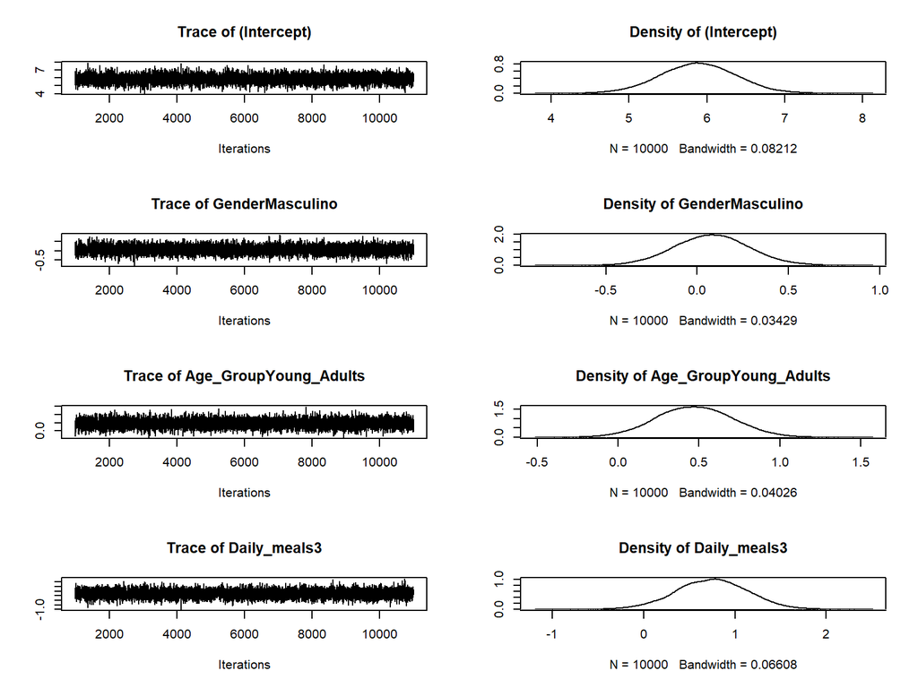

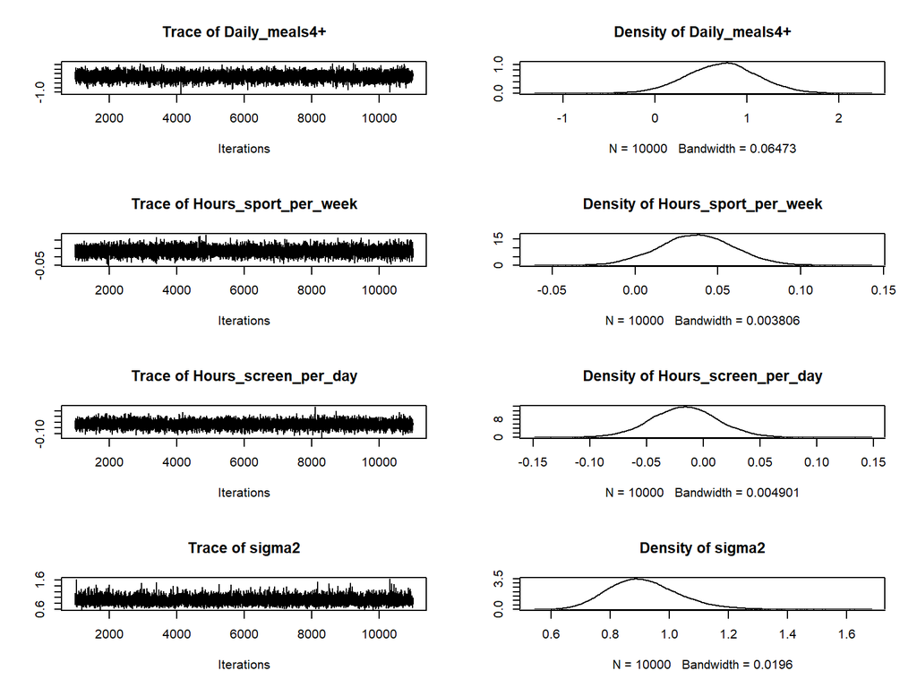

```r
plot(bayes.model)
```

The trace plots are used to estimate the posterior distribution of the parameters,the shapes seem to mix well across the parameter space which indicates a good convergenceof the chain.

The density plots shows the estimated density of the posterior distribution for each model parameter.

### ACF Plots

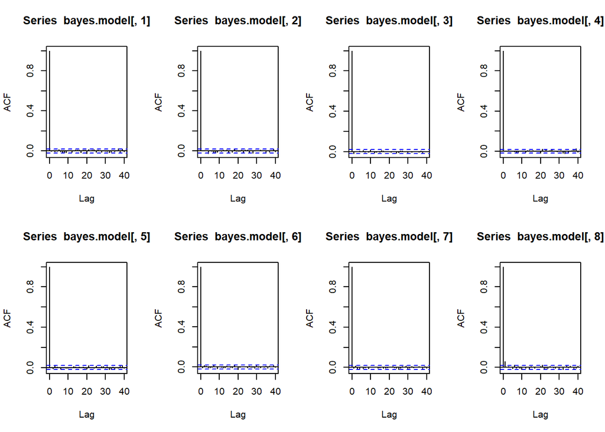

```r
par(mfrow = c(2,4))
acf(bayes.model[,1])
acf(bayes.model[,2])
acf(bayes.model[,3])
acf(bayes.model[,4])
acf(bayes.model[,5])
acf(bayes.model[,6])
acf(bayes.model[,7])
acf(bayes.model[,8])
```

The ACF plot displays the correlation between each parameter’s values at different lags, and from them, we can assess there is no autocorrelation, and indeed, converge.

## Real-Case Scenario

For the first Case Scenario, we are going to obtain the usual hours of sleep from a person with the following characteristics:

- Female (Femenino).
- Adult.
- Eats 2 meals per day.
- Does not participate in sports (0 hours of sports per week).
- Spends 12 hours in front of a screen per day.

```r
Gender.new <- "Femenino"
Age_Group.new <- "Adults"
Daily_meals.new <- "2"
Hours_sport_per_week.new <- 0
Hours_screen_per_day.new <- 12
```

We need to convert the factor variables into dummies:

```r
Gender.new <- ifelse(Gender.new == "Masculino", 1, 0)
Age_Group.new <- ifelse(Age_Group.new == "Young_Adults", 1, 0)
Daily_meals.new_3 <- ifelse(Daily_meals.new == "3", 1, 0)
Daily_meals.new_4 <- ifelse(Daily_meals.new == "4+", 1, 0)
```

We construct the new observation vector:

```r
x.new <- c(1, Gender.new, Age_Group.new, Daily_meals.new_3, Daily_meals.new_4, Hours_sport_per_week.new, Hours_screen_per_day.new)
```

And predict using the mean:

```r
x_pred <- x.new %*% apply(beta, 2, mean)
print(x_pred)
```

```
##          [,1]
## [1,] 5.681486
```

**5.681486 hours** which falls below the mean average. This result aligns with expectations, as the characteristics utilized in this scenario were identified by the model as factors associated with reduced sleep compared to others.

Now this interval shows where the value is likely to fall with a 95% confidence.

```r
quantile(x.new %*% t(beta), probs = c(0.025, 0.975))
```

```
##     2.5%    97.5%
## 4.735917 6.629596
```

Let’s calculate the predictive distribution and the predictive interval that tells where future observations will be likely to fall.

```r
y.pred <- rnorm(n = dim(beta)[1], mean = x.new %*% t(beta), sd = sqrt(sigma2))
quantile(y.pred, probs = c(0.025, 0.975))
```

```
##     2.5%    97.5%
## 3.632528 7.805099
```

As can be seen, the interval for the predictive interval is wider than the other confidence interval.

### Another Case Scenario

Finally, let’s do the same experiment but this time using completely different characteristics which will luckily result in more hours of sleep:

- Gender: Male (coded as 1)
- Age Group: Young Adult (coded as 1)
- Daily Meals: 4+
- Hours of Sport per Week: 16
- Hours of Screen Time per Day: 3

```r
Gender.new <- 1
Age_Group.new <- 1
Daily_meals.new <- "4+"
Hours_sport_per_week.new <- 16
Hours_screen_per_day.new <- 3
Gender.new <- ifelse(Gender.new == 1, 1, 0)
Age_Group.new <- ifelse(Age_Group.new == 1, 1, 0)
Daily_meals.new_3 <- ifelse(Daily_meals.new == "3", 1, 0)
Daily_meals.new_4 <- ifelse(Daily_meals.new == "4+", 1, 0)
x.new <- c(1, Gender.new, Age_Group.new, Daily_meals.new_3, Daily_meals.new_4,
           Hours_sport_per_week.new, Hours_screen_per_day.new)
x_pred <- x.new %*% apply(beta, 2, mean)
print(x_pred)
```

```
##          [,1]
## [1,] 7.703614
```

Approximately **7.7 hours**. Way more than the previous scenario.

The confidence and predictive intervals are the following:

```r
quantile(x.new %*% t(beta), probs = c(0.025, 0.975))
```

```
##     2.5%    97.5%
## 7.086145 8.317578
```

```r
y.pred <- rnorm(n = dim(beta)[1], mean = x.new %*% t(beta), sd = sqrt(sigma2))
quantile(y.pred, probs = c(0.025, 0.975))
```

```
##     2.5%    97.5%
## 5.756070 9.718232
```

## Conclusions

In this study, an analysis of factors influencing sleep duration revealed some uncertainty in the observed effects and in the model in general, since zero fell inside the credible intervals of most of the variables in a 95% confidence. One prominent factor contributing to this uncertainty is the relatively small sample size, which was obtained through self-collection. The limited number of observations may challenged the ability to capture the full variability, leading to wider credible intervals and increased uncertainty in the estimated effects of predictors.

To address this limitation and improve the robustness of future analyses the sample size can be increased so that this experiment can be repeated with larger datasets which will provide a more representative sample and enhance the statistical power of the analysis.

By employing Bayesian linear regression, we were able to explore the relationship between various predictors and the number of hours slept per day. Here are the **key conclusions** drawn from our investigation:

**Gender and Age Differences:** There are slight differences in sleep duration between genders, with males sleeping more than females on average. Additionally, young adults tend to sleep slightly longer than adults.

**Impact of Daily Habits:** The frequency of daily meals also influences sleep duration, with individuals consuming more meals tending to sleep longer.